# VPS Customer churn prediction

19-8-2021

## As an introduction

[figure not shown]

I did not expect that this interesting task would be intertwined with my long-awaited trip to Poland. So I start with Hello to everyone in front of the old locomotive in the city of Przeworsk. I tried my best to accomplish this task.

## Presentantion outline

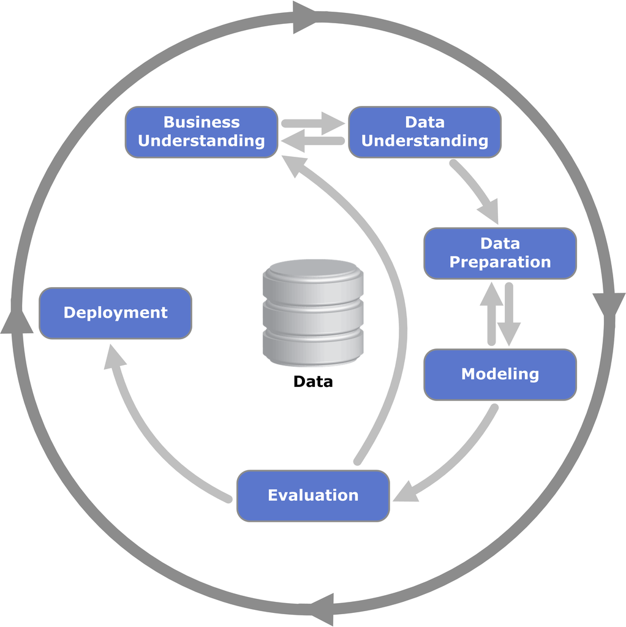

Cross Industry Standard Process for Data Mining (Wirth & Hipp, 2000)

## Business understanding

Company X sells a Virtual Private Server (VPS) as a service. The company wants to know which customers intend to leave VPS so they can devise an appropriate customer re-engagement strategy before it’s too late.

## Data understanding

```r
library(tidyverse)
library(tidymodels)
vps <- read_csv("./data/vps_churn_data.txt") %>%
  mutate(is_churn = factor(ifelse(is_churn == 0,
                                  "No", "Yes")))

vps %>% dim()
```

```
## [1] 283  23
```

In this work we use *R* and *tidy-* libraries. All commands are visible to facilitate the verification of the presentation. We see that the dataset is composed of 283 observations described with 23 variables.

## Data understanding cont.

The two classes (is_churn = Yes and is_churn = No) are almost equally distributed.

```r
vps %>%
  count(is_churn) %>%
  mutate(prop = n/sum(n))
```

```
## # A tibble: 2 x 3
##   is_churn     n  prop
##   <fct>    <int> <dbl>
## 1 No         148 0.523
## 2 Yes        135 0.477
```

## Data understanding cont.

The dataset is complete - there are no missing values we have to deal with.

```r
vps %>% is.na() %>% colSums() %>% head(6)
```

```
##                         id          cpu_load_mean_m_3
##                          0                          0
##  disk_octets_read_mean_m_3 disk_octets_write_mean_m_3
##                          0                          0
##     disk_ops_read_mean_m_3    disk_ops_write_mean_m_3
##                          0                          0
```

## Data understanding cont.

We check whether first variable can serve as a “good” predictor.

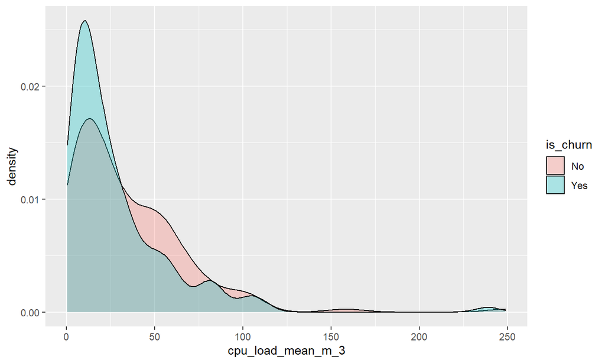

## Data understanding cont.

We check whether last variable can serve as a “good” predictor.

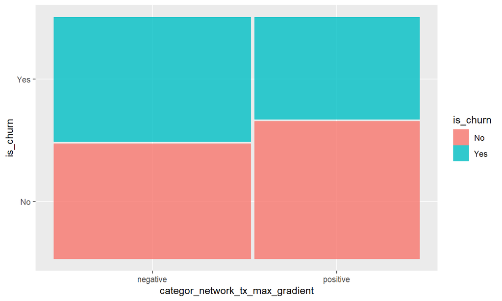

## Data preparation

We split our data into training and test datasets.

```r
set.seed(1234)
vps_split <- initial_split(vps, prop = 0.6,
                           strata = is_churn)
vps_split
```

```
## <Analysis/Assess/Total>
## <169/114/283>
```

## Data preparation cont.

We check the observations used for training.

```
## Rows: 169
## Columns: 23
## $ id                                   <dbl> 102, 104, 105, 106, 107, 113, 115~
## $ cpu_load_mean_m_3                    <dbl> 248.935914, 85.793333, 39.394301,~
## $ disk_octets_read_mean_m_3            <dbl> 19.37152776, 15.49345957, 11.3651~
## $ disk_octets_write_mean_m_3           <dbl> 31.97102730, 14.87482307, 20.1531~
## $ disk_ops_read_mean_m_3               <dbl> 213.1603226, 280.2319355, 793.136~
## $ disk_ops_write_mean_m_3              <dbl> 194.55827960, 9.59537634, 55.0200~
## $ network_rx_mean_m_3                  <dbl> 1.72831136, 0.01669605, 9.8179840~
## $ network_tx_mean_m_3                  <dbl> 1.35480347, 0.17150479, 2.1123576~
## $ cpu_load_monthly_mean_delta          <dbl> 9.67491398, -3.55555556, 14.84707~
## $ network_tx_monthly_mean_delta        <dbl> -0.19059860, -0.06342757, 1.93625~
## $ network_rx_monthly_mean_delta        <dbl> -0.33151170, -0.00248126, 9.32541~
## $ disk_ops_read_monthly_mean_delta     <dbl> -22.40323297, -3.42950896, -123.1~
## $ disk_ops_write_monthly_mean_delta    <dbl> -26.08083154, -0.67784588, -0.952~
## $ disk_octets_write_monthly_mean_delta <dbl> -2.34339560, -0.46046894, 17.1099~
## $ disk_octets_read_monthly_mean_delta  <dbl> -0.53592374, -0.43877029, 7.60239~
## $ cpu_load_max_gradient                <dbl> 0.37335290, -0.09440948, 0.390981~
## $ disk_octets_read_max_gradient        <dbl> -0.01865949, -0.01649244, 0.24210~
## $ disk_octets_write_max_gradient       <dbl> -0.07624555, -0.01788293, 0.54836~
## $ disk_ops_read_max_gradient           <dbl> -0.16357924, -0.15304266, -4.4040~
## $ disk_ops_write_max_gradient          <dbl> -0.44157712, -0.02211370, 0.19133~
## $ network_rx_max_gradient              <dbl> -0.02173184, -0.00011261, 0.24408~
## $ network_tx_max_gradient              <dbl> -0.00538242, -0.00242201, 0.02221~
## $ is_churn                             <fct> No, No, No, No, No, No, No, No, N~
```

## Data preparation cont.

We write recipe to prepare our data for training. Steps are described in comments.

```r
vps_recipe <- training(vps_split) %>% # on which data
  recipe(is_churn ~.) %>% # training formula
  step_rm(id) %>% # step remove id column
  # remove variables highly correlated with other vars
  step_corr(all_predictors()) %>%
  # make vars to be of mean zero
  step_center(all_predictors(), -all_outcomes()) %>%
  # make vars to be standard dev of 1
  step_scale(all_predictors(), -all_outcomes()) %>%
  prep() # execute transformations
```

## Data preparation cont.

We use previously written recipe to prepare *training* data.

```r
vps_training <- juice(vps_recipe)
vps_training %>% select(1:10) %>% glimpse()
```

```
## Rows: 169
## Columns: 10
## $ cpu_load_mean_m_3                 <dbl> 6.9540144, 1.7162092, 0.2265362, -0.~
## $ disk_octets_read_mean_m_3         <dbl> 0.7810093, 0.5526101, 0.3094756, -0.~
## $ disk_octets_write_mean_m_3        <dbl> 2.65330241, 1.03512783, 1.53473031, ~
## $ disk_ops_read_mean_m_3            <dbl> 0.02212873, 0.18825577, 1.45864909, ~
## $ disk_ops_write_mean_m_3           <dbl> 0.66829422, -0.28438486, -0.05041855~
## $ network_rx_mean_m_3               <dbl> -0.10276295, -0.19317908, 0.32457424~
## $ network_tx_mean_m_3               <dbl> -0.190306768, -0.257458023, -0.14731~
## $ network_tx_monthly_mean_delta     <dbl> -0.016170786, 0.050695427, 1.1021246~
## $ disk_ops_read_monthly_mean_delta  <dbl> -0.1108472650, -0.0056825168, -0.669~
## $ disk_ops_write_monthly_mean_delta <dbl> -0.1447599445, 0.0480557968, 0.04596~
```

## Data preparation cont.

We use previously written recipe to prepare *test* data.

```r
vps_testing <- vps_recipe %>%
  bake(testing(vps_split))
vps_testing %>% select(1:10) %>% glimpse()
```

```
## Rows: 114
## Columns: 10
## $ cpu_load_mean_m_3                 <dbl> -0.608674397, -0.495593320, 1.153068~
## $ disk_octets_read_mean_m_3         <dbl> 1.92677245, -0.35968528, 0.70663120,~
## $ disk_octets_write_mean_m_3        <dbl> -0.36157310, -0.34097917, 1.22049786~
## $ disk_ops_read_mean_m_3            <dbl> 0.328112376, -0.505637827, 0.7647586~
## $ disk_ops_write_mean_m_3           <dbl> -0.29893573, -0.31941648, 0.28212289~
## $ network_rx_mean_m_3               <dbl> -0.1932091, -0.1915187, -0.1542211, ~
## $ network_tx_mean_m_3               <dbl> -0.2665257913, -0.2420052458, -0.083~
## $ network_tx_monthly_mean_delta     <dbl> 0.0849835086, 0.0056656905, 1.360358~
## $ disk_ops_read_monthly_mean_delta  <dbl> 1.85174047, 0.01227514, 0.13092621, ~
## $ disk_ops_write_monthly_mean_delta <dbl> 0.09257490, 0.05443283, 0.11194293, ~
```

## Modeling & Evaluation

Further we will interlace **Modeling** and **Evaluation** steps for selected algorithms. Previously defined *training* set is used to train models, the other *testing* for testing. Predicting power of each model is measured with *Accuracy* and *Area under curve* measures.

## Modeling & Evaluation cont.

We start from *Null model* - assumption that no one will churn.

```r
null_model <- null_model(mode = "classification") %>%
  set_engine("parsnip") %>%
  fit(is_churn ~ ., data = vps_training)
predict(null_model, vps_testing, type = "prob") %>%
  bind_cols(predict(null_model, vps_testing)) %>%
  bind_cols(select(vps_testing, is_churn)) %>%
  metrics(is_churn, .pred_No, estimate = .pred_class)
```

```
## # A tibble: 4 x 3
##   .metric     .estimator .estimate
##   <chr>       <chr>          <dbl>
## 1 accuracy    binary         0.526
## 2 kap         binary         0
## 3 mn_log_loss binary         0.692
## 4 roc_auc     binary         0.5
```

## Modeling & Evaluation cont.

From now on our goal is to beat 0.526 in accuracy, 0.5 in AUC and bend the ROC curve up.

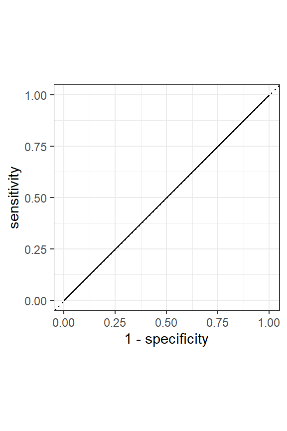

## Modeling & Evaluation cont.

We will try to train `svm_poly()` - polynomial support vector machines model.

```r
vps_svm <- svm_poly(mode = "classification") %>%
  set_engine("kernlab") %>%
  fit(is_churn ~ ., data = vps_training)
```

## Modeling & Evaluation cont.

The `svm_poly()` model is performing worse than `null_model()`.

```r
predict(vps_svm, vps_testing, type = "prob") %>%
  bind_cols(predict(vps_svm, vps_testing)) %>%
  bind_cols(select(vps_testing, is_churn)) %>%
  metrics(is_churn, .pred_No, estimate = .pred_class)
```

```
## # A tibble: 4 x 3
##   .metric     .estimator .estimate
##   <chr>       <chr>          <dbl>
## 1 accuracy    binary        0.509
## 2 kap         binary        0.0414
## 3 mn_log_loss binary        0.693
## 4 roc_auc     binary        0.480
```

## Modeling & Evaluation cont.

We will try to train `logistic_reg()` - generalized linear model for binary outcomes.

```r
vps_lreg <- logistic_reg(mode = "classification",
                         engine = "glm") %>%
  fit(is_churn ~ ., data = vps_training)
```

## Modeling & Evaluation cont.

The `logistic_reg()` model is performing worse in accuracy but better in AUC than `null_model()`.

```r
predict(vps_lreg, vps_testing, type = "prob") %>%
  bind_cols(predict(vps_lreg, vps_testing)) %>%
  bind_cols(select(vps_testing, is_churn)) %>%
  metrics(is_churn, .pred_No, estimate = .pred_class)
```

```
## # A tibble: 4 x 3
##   .metric     .estimator .estimate
##   <chr>       <chr>          <dbl>
## 1 accuracy    binary        0.518
## 2 kap         binary        0.0509
## 3 mn_log_loss binary        0.807
## 4 roc_auc     binary        0.521
```

## Modeling & Evaluation cont.

We will try to train `rand_forest()` - model that creates a large number of decision trees.

```r
vps_rf <-  rand_forest(mode = "classification") %>%
  set_engine("randomForest") %>%
  fit(is_churn ~ ., data = vps_training)
```

## Modeling & Evaluation cont.

The `rand_forest()` model is performing better in accuracy and AUC than `null_model()`.

```r
predict(vps_rf, vps_testing, type = "prob") %>%
  bind_cols(predict(vps_rf, vps_testing)) %>%
  bind_cols(select(vps_testing, is_churn)) %>%
  metrics(is_churn, .pred_No, estimate = .pred_class)
```

```
## # A tibble: 4 x 3
##   .metric     .estimator .estimate
##   <chr>       <chr>          <dbl>
## 1 accuracy    binary         0.596
## 2 kap         binary         0.191
## 3 mn_log_loss binary         0.671
## 4 roc_auc     binary         0.631
```

## Modeling & Evaluation cont.

Accuracy, AUC and ROC curve has been bent up comparing to null model.

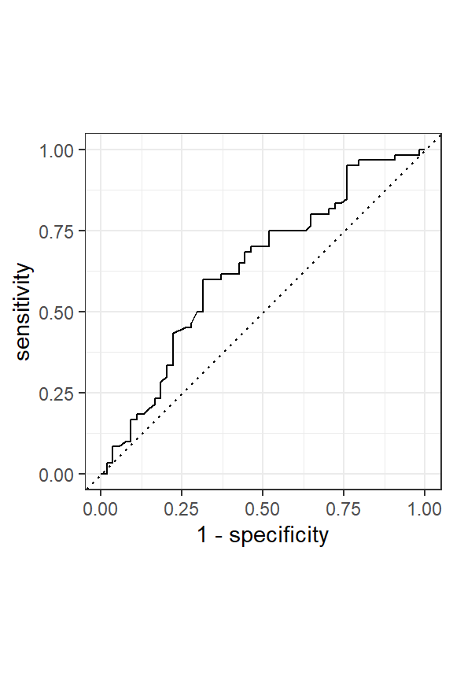

## Deployment

The last model will be used to make predictions on production data. Output is available in https://github.com/JacekPardyak/vps repository.

```r
production <- read_csv("./data/vps_test_data.txt")
vps_production <- vps_recipe %>%
  bake(production)

tmp <- predict(vps_rf, vps_production) %>%
  rename(is_churn = .pred_class) %>%
  mutate(is_churn = ifelse(is_churn == "Yes", 1, 0 ))

production %>% select(! one_of('is_churn')) %>%
  bind_cols(tmp) %>%
  write_csv("./data/vps_test_data_pred.txt")
```

## Further steps

In other circumstances, I would go further with:

- feature engineering - combining and transforming further existing variables,
- tuning parameters of already tested algorithms used to train models,
- try another algorithms, such as: Boosted tree (XGBoost), K-nearest neighbor, Neural network with Keras
- demonstrate how to use **SparkR** (R on Spark)